# Hyperparameter Tuning & ML Pipelines

## About me:

I am Atul Saurav (@twtAtul),

- Lead Genworth Financials' Data Engineering Team
- MS in Decison Analytics, VCU DAPT class of 2019
- Passionate about learning, data and everything around it

You can also find me on LinkedIn

## What is this talk about?

- Building Machine Learning Models
- Python specific
- scikit-learn based models

## What is this talk not about?

- Data Cleansing
- Feature Engineering
- Deep Learning
- Other exciting stuff that is difficult to cover in 1 meetup!

# All models are wrong but some are useful

> </br> </br>

> Box, G. E. P. (1979), "Robustness in the strategy of scientific model building", in Launer, R. L.; Wilkinson, G. N., Robustness in Statistics, Academic Press, pp. 201–236.

## Reality is complex -

- too many factors influence outcome
- factors difficult to measure accurately and objectively
- not all factors may be known

## How do we build useful models?

## How do we minimize our effort in model building?

## Approach

- Use toy datasets for illustration and visualization
- Use real dataset for demonstrating application efficacy

## Scikit-learn API Overview

- All methods are implemented as estimators
- All estimators have a `.fit()` method
- All supervised estimators have `.predict()` method
- All unsupervised estimators have `.transform()` method

| ``model.predict`` | ``model.transform`` |
| --- | --- |
| Classification | Preprocessing |
| Regression | Dimensionality Reduction |
| Clustering | Feature Extraction |
|  | Feature Selection |

### Usual High Level Flow

```python
from sklearn.family import SomeModel
myModel = SomeModel()
myModel.fit(X_train,y_train)

# supervised
myModel.predict(X_test)
myModel.score(X_test, y_test)

## unsupervised
myModel.transform(X_train)
```

## Problem Statement

- Classify data into 2 groups based on already observed groupings
- Using house price data, predict if the price of the given house will be >= 500K

### Binary Classification Problem

### Toy Example

```python
from sklearn.datasets import make_blobs

scaled_X, scaled_y = make_blobs(centers=2, random_state=0)
scaled_X[:,0] = 10* scaled_X[:,0] + 3
X, y = make_blobs(centers=2, random_state=0)

print('X ~ n_samples x n_features:', X.shape)
print('y ~ n_samples:', y.shape)
```

```
X ~ n_samples x n_features: (100, 2)
y ~ n_samples: (100,)
```

### Visualize Data

```
Text(0.5,0,'first feature')
```

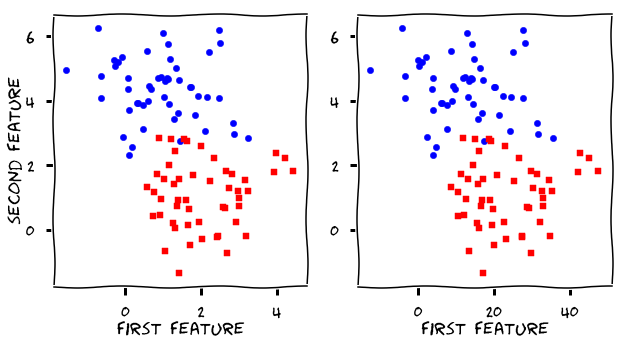

```python
fig, (ax0, ax1) = plt.subplots(nrows=1, ncols=2, figsize=(10,5))

ax0.scatter(X[y == 0, 0], X[y == 0, 1], c='blue', s=40, label='0')
ax0.scatter(X[y == 1, 0], X[y == 1, 1], c='red', s=40, label='1', marker='s')
ax0.set_xlabel('first feature')
ax0.set_ylabel('second feature')

ax1.scatter(scaled_X[scaled_y == 0, 0], scaled_X[scaled_y == 0, 1], c='blue', s=40, label='0')
ax1.scatter(scaled_X[scaled_y == 1, 0], scaled_X[scaled_y == 1, 1], c='red', s=40, label='1', marker='s')
ax1.set_xlabel('first feature')
```

### Create Training and Test Set

**Training Set** - Data used to train the model

**Test Set** - Data held out in the very beginning for testing model performance. This data should not be touched until final scoring

```python
from sklearn.model_selection import train_test_split

X_train, X_test, y_train, y_test = train_test_split(X, y,
                                                    test_size=0.25,
                                                    random_state=1234,
                                                    stratify=y)
scaled_X_train, scaled_X_test, \
scaled_y_train, scaled_y_test = train_test_split(scaled_X,
                                                    scaled_y,
                                                    test_size=0.25,
                                                    random_state=1234,
                                                    stratify=y)
```

```python
X_train.shape
```

```
(75, 2)
```

```python
y_train.shape
```

```
(75,)
```

### Train a Nearest Neighbor Classifier - 1 Neighbor

Overfit!!

```python
from sklearn.neighbors import KNeighborsClassifier
knn = KNeighborsClassifier(n_neighbors=1)

knn.fit(X_train, y_train)
```

```
KNeighborsClassifier(algorithm='auto', leaf_size=30, metric='minkowski',
           metric_params=None, n_jobs=1, n_neighbors=1, p=2,
           weights='uniform')
```

```python
scaled_knn = KNeighborsClassifier(n_neighbors=1)
scaled_knn.fit(scaled_X_train, scaled_y_train)
```

```
KNeighborsClassifier(algorithm='auto', leaf_size=30, metric='minkowski',
           metric_params=None, n_jobs=1, n_neighbors=1, p=2,
           weights='uniform')
```

### Comapre Model Performance

```python
knn.score(X_test, y_test)
```

```
1.0
```

```python
scaled_knn.score(scaled_X_test, scaled_y_test)
```

```
0.95999999999999996
```

### Visualize Model - regular

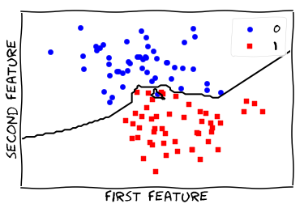

```python
from figures import plot_2d_separator
plt.scatter(X[y == 0, 0], X[y == 0, 1], c='blue', s=40, label='0')
plt.scatter(X[y == 1, 0], X[y == 1, 1], c='red', s=40, label='1', marker='s')

plt.xlabel("first feature")
plt.ylabel("second feature")
plot_2d_separator(knn, X)
_ = plt.legend()
```

### Visualize Model - scaled

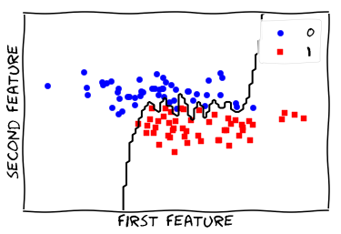

```python
from figures import plot_2d_separator
plt.scatter(scaled_X[scaled_y == 0, 0], scaled_X[scaled_y == 0, 1], c='blue', s=40, label='0')
plt.scatter(scaled_X[scaled_y == 1, 0], scaled_X[scaled_y == 1, 1], c='red', s=40, label='1', marker='s')

plt.xlabel("first feature")
plt.ylabel("second feature")
plot_2d_separator(scaled_knn, scaled_X)
_ = plt.legend()
```

### Revelation

### Scale of various features matters!

### Train Nearest Neighbor Classifier - 10 neighbors

```python
from sklearn.neighbors import KNeighborsClassifier
knn = KNeighborsClassifier(n_neighbors=10)

knn.fit(X_train, y_train)
```

```
KNeighborsClassifier(algorithm='auto', leaf_size=30, metric='minkowski',
           metric_params=None, n_jobs=1, n_neighbors=10, p=2,
           weights='uniform')
```

```python
scaled_knn = KNeighborsClassifier(n_neighbors=10)
scaled_knn.fit(scaled_X_train, scaled_y_train)
```

```
KNeighborsClassifier(algorithm='auto', leaf_size=30, metric='minkowski',
           metric_params=None, n_jobs=1, n_neighbors=10, p=2,
           weights='uniform')
```

### Comapre Model Performance

```python
knn.score(X_test, y_test)
```

```
0.83999999999999997
```

```python
scaled_knn.score(scaled_X_test, scaled_y_test)
```

```
0.80000000000000004
```

### Visualize Model - regular

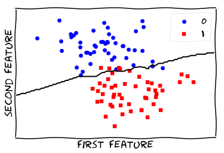

```python
from figures import plot_2d_separator
plt.scatter(X[y == 0, 0], X[y == 0, 1], c='blue', s=40, label='0')
plt.scatter(X[y == 1, 0], X[y == 1, 1], c='red', s=40, label='1', marker='s')

plt.xlabel("first feature")
plt.ylabel("second feature")
plot_2d_separator(knn, X)
_ = plt.legend()
```

### Visualize Model - scaled

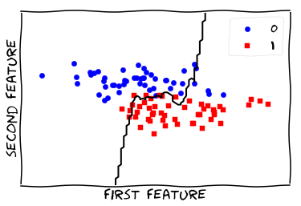

```python
from figures import plot_2d_separator
plt.scatter(scaled_X[scaled_y == 0, 0], scaled_X[scaled_y == 0, 1], c='blue', s=40, label='0')
plt.scatter(scaled_X[scaled_y == 1, 0], scaled_X[scaled_y == 1, 1], c='red', s=40, label='1', marker='s')

plt.xlabel("first feature")
plt.ylabel("second feature")
plot_2d_separator(scaled_knn, scaled_X)
_ = plt.legend()
```

### Revelation

### Number of neighbors matters as well!

### Tunning # of Neighbors

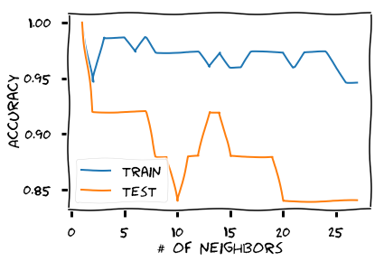

```python
train_scores = []
test_scores = []
n_neighbors = range(1,28)
for neighbor in n_neighbors:
    knn = KNeighborsClassifier(n_neighbors=neighbor)
    knn.fit(X_train, y_train)
    train_scores.append(knn.score(X_train, y_train))
    test_scores.append(knn.score(X_test, y_test))

plt.plot(n_neighbors, train_scores, label='train')
plt.plot(n_neighbors, test_scores, label='test')
plt.ylabel('Accuracy')
plt.xlabel('# of neighbors')
plt.legend();plt.show()
```

### But Wait!! Is that Hyperparameter Tuning?

# No

### Hyperparameter tuning is part of Model building and Test Data should not be used in model build

### Hyperparameter Tuning should be performed using Validation Set - a subset of training set

### Real Life Example - Housing Data

```python
data = pd.read_csv('new_train.csv')
data.columns = [ x.lower().replace('.','_') for x in data.columns]
data.head().T
```

|  | 0 | 1 | 2 | 3 | 4 |
| --- | --- | --- | --- | --- | --- |
| id | 1 | 2 | 3 | 4 | 5 |
| sale_type | MLS Listing | MLS Listing | MLS Listing | MLS Listing | MLS Listing |
| sold_date | NaN | NaN | NaN | NaN | NaN |
| property_type | Condo/Co-op | Single Family Residential | Single Family Residential | Single Family Residential | Single Family Residential |
| city | Kew Gardens | Anaheim | Howard Beach | Aliso Viejo | Orlando |
| state | NY | CA | NY | CA | FL |
| zip | 11415 | 92807 | 11414 | 92656 | 32837 |
| beds | 0 | 7 | 3 | 4 | 3 |
| baths | 1 | 5.5 | 1.5 | 4.5 | 2 |
| location | The Texas | 91 - Sycamore Canyon | Howard Beach | AV - Aliso Viejo | Orlando |
| square_feet | NaN | 7400 | NaN | 3258 | 1596 |
| lot_size | NaN | 56628 | 2400 | 5893 | 5623 |
| year_built | 1956 | 2000 | 1950 | 2011 | 1994 |
| days_on_market | 1 | 2 | 15 | 6 | 8 |
| x__square_feet | NaN | 514 | NaN | 457 | 166 |
| hoa_month | NaN | NaN | NaN | 258 | 64 |
| status | Active | Active | Active | Active | Active |
| next_open_house_start_time | March-11-2018 01:00 PM | NaN | NaN | NaN | NaN |
| next_open_house_end_time | March-11-2018 03:00 PM | NaN | NaN | NaN | NaN |
| source | MLSLI | CRMLS | MLSLI | CRMLS | MFRMLS |
| favorite | N | N | N | N | N |
| interested | Y | Y | Y | Y | Y |
| latitude | 40.7 | 33.8 | 40.7 | 33.6 | 28.4 |
| longitude | -73.8 | -117.8 | -73.8 | -117.7 | -81.4 |
| target | False | True | True | True | False |

### Some Observations

```python
data.info()
```

```
<class 'pandas.core.frame.DataFrame'>
RangeIndex: 19318 entries, 0 to 19317
Data columns (total 25 columns):
id                            19318 non-null int64
sale_type                     19318 non-null object
sold_date                     0 non-null float64
property_type                 19318 non-null object
city                          19306 non-null object
state                         19318 non-null object
zip                           19271 non-null object
beds                          18216 non-null float64
baths                         18053 non-null float64
location                      18773 non-null object
square_feet                   15693 non-null float64
lot_size                      10267 non-null float64
year_built                    16950 non-null float64
days_on_market                18328 non-null float64
x__square_feet                15693 non-null float64
hoa_month                     7553 non-null float64
status                        19318 non-null object
next_open_house_start_time    933 non-null object
next_open_house_end_time      933 non-null object
source                        19318 non-null object
favorite                      19318 non-null object
interested                    19318 non-null object
latitude                      19318 non-null float64
longitude                     19318 non-null float64
target                        19318 non-null bool
dtypes: bool(1), float64(11), int64(1), object(12)
memory usage: 3.6+ MB
```

### What's different?

- Not all features are numeric - **Categorical Variables**
- Lot of missing data points

### More Revalations:

### scikit-learn models need data to be numeric/float

### scikit-learn models implicitly cannot handle missing values

### Final Revelation

### Any transformation applied on the training set to handle first 3 revelations should later be applied on the test set as well

```python
del(data['sold_date'])
del(data['next_open_house_start_time'])
del(data['next_open_house_end_time'])
```

## Summary so far

We need to string following steps into a managable fashion to build effective models

- Handle missing data
- Handle different scales across features
- Handle categorical data

### - Pipelines

#### But then also tune the model

- split training data into (cross)validation sets
- search best values for hyperparameters for optimal model performance

### - GridSearch

### More on Pipelines and GridSearchCV

- also known as meta-estimators in scikit-learn
- they inherit the properties of the last estimator used
- pipeline is used to chain multiple estimator into one pipe so output of one flows as input of next
- GridSearchCV is used to search on a hyperparameter grid the model with the best score

### Making ML Pipelines

```python
from sklearn.pipeline import make_pipeline
make_pipeline( CategoricalTransformer(columns=cat_cols), DummyClassifier("most_frequent"))
```

This will inherit the properties of DummyClassifier

[figure not shown]

Image Source: [SciPy 2016 Scikit-learn Tutorial](https://github.com/amueller/scipy-2017-sklearn/)

## Back to real life housing classification problem

### Which features have less than 20% missing values?

```python
d = pd.DataFrame(null_pct(data), index=['null_pct']).T.sort_values('null_pct')
d[(d.null_pct< .2 )]
```

|  | null_pct |
| --- | --- |
| id | 0.000000 |
| latitude | 0.000000 |
| interested | 0.000000 |
| favorite | 0.000000 |
| source | 0.000000 |
| status | 0.000000 |
| longitude | 0.000000 |
| target | 0.000000 |
| state | 0.000000 |
| property_type | 0.000000 |
| sale_type | 0.000000 |
| city | 0.000621 |
| zip | 0.002433 |
| location | 0.028212 |
| days_on_market | 0.051248 |
| beds | 0.057045 |
| baths | 0.065483 |
| year_built | 0.122580 |
| square_feet | 0.187649 |
| x__square_feet | 0.187649 |

### Set features to work with

```python
new_features = ['id', 'favorite', 'interested', 'latitude', 'longitude', 'status', 'property_type', 'sale_type', 'source',
                'state', 'beds', 'baths', 'year_built', 'x__square_feet', 'square_feet', 'target']

sub_data = data[new_features]
sub_data.head(3)
```

|  | id | favorite | interested | latitude | longitude | status | property_type | sale_type | source | state | beds | baths | year_built | x__square_feet | square_feet | target |
| --- | --- | --- | --- | --- | --- | --- | --- | --- | --- | --- | --- | --- | --- | --- | --- | --- |
| 0 | 1 | N | Y | 40.7 | -73.8 | Active | Condo/Co-op | MLS Listing | MLSLI | NY | 0.0 | 1.0 | 1956.0 | NaN | NaN | False |
| 1 | 2 | N | Y | 33.8 | -117.8 | Active | Single Family Residential | MLS Listing | CRMLS | CA | 7.0 | 5.5 | 2000.0 | 514.0 | 7400.0 | True |
| 2 | 3 | N | Y | 40.7 | -73.8 | Active | Single Family Residential | MLS Listing | MLSLI | NY | 3.0 | 1.5 | 1950.0 | NaN | NaN | True |

### Set model Inputs

```python
X = sub_data[['favorite', 'interested', 'latitude', 'longitude', 'status', 'property_type', 'sale_type',
                    'source', 'state', 'beds', 'baths', 'year_built', 'x__square_feet', 'square_feet']]
y = sub_data.target
```

```python
cat_cols = ['favorite', 'interested', 'status', 'property_type', 'sale_type', 'source', 'state']
```

### Establish base case for prediction

```python
dummy_pipe = make_pipeline( CategoricalTransformer(columns=cat_cols), DummyEncoder(), DummyClassifier("most_frequent"))
cross_val_score(dummy_pipe, X, y)
```

```
array([ 0.68984678,  0.68996295,  0.68996295])
```

### Create training and test set

```python
X_train, X_test, y_train, y_test = train_test_split(X,y, random_state=42 )
```

### Support Vector Machine

```python
Cs = [ 1, 10, 100, 500, 750]
gammas = [0.0005, 0.001, 0.01, .1, 1]
param_grid = {'svc__C': Cs, 'svc__gamma' : gammas}
```

```python
svc_pipe = make_pipeline( CategoricalTransformer(columns=cat_cols), DummyEncoder(), Imputer(strategy='median'),  StandardScaler(), SVC(random_state=42) )
```

```python
svmgrid = GridSearchCV(svc_pipe, param_grid, cv=5, n_jobs=-1, verbose=3)#, scoring=roc_auc_scorer)
svmgrid.fit(X_train, y_train)
```

[output not shown]

```
[Parallel(n_jobs=-1)]: Done  16 tasks      | elapsed:   55.7s
```

[output not shown]

[output cut: 155 more lines]

[output not shown]

```
[Parallel(n_jobs=-1)]: Done 125 out of 125 | elapsed:  5.4min finished
```

```
GridSearchCV(cv=5, error_score='raise',
       estimator=Pipeline(memory=None,
     steps=[('categoricaltransformer', CategoricalTransformer(columns=['favorite', 'interested', 'status', 'property_type', 'sale_type', 'source', 'state'])), ('dummyencoder', DummyEncoder()), ('imputer', Imputer(axis=0, copy=True, missing_values='NaN', strategy='median', verbose=0)), ('standardscal…
  max_iter=-1, probability=False, random_state=42, shrinking=True,
  tol=0.001, verbose=False))]),
       fit_params=None, iid=True, n_jobs=-1,
       param_grid={'svc__C': [1, 10, 100, 500, 750], 'svc__gamma': [0.0005, 0.001, 0.01, 0.1, 1]},
       pre_dispatch='2*n_jobs', refit=True, return_train_score='warn',
       scoring=None, verbose=3)
```

```python
roc_auc_score(y_test, svmgrid.predict(X_test))
```

```
0.90180396517871109
```

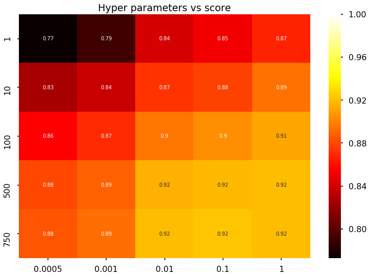

```python
scores = svmgrid.cv_results_['mean_test_score'].reshape(5,5)
sns.heatmap(scores, vmax=1, xticklabels=param_grid['svc__gamma'], yticklabels=param_grid['svc__C'], cmap='hot', annot=True)
plt.title('Hyper parameters vs score')
plt.show()
```

### Adaboost

```python
from sklearn.ensemble import AdaBoostClassifier
```

```python
n_estimators = [ 1500, 1570, 2000, 2250, 3000, 3250, 3500]
param_grid = {'adaboostclassifier__n_estimators': n_estimators}
```

```python
abpipe = make_pipeline(CategoricalTransformer(columns=cat_cols), DummyEncoder(), Imputer(strategy='median'), StandardScaler(),
                   AdaBoostClassifier())
```

```python
abgrid = GridSearchCV(abpipe, param_grid, cv=5, n_jobs=-1, verbose=3, scoring=roc_auc_scorer)
abgrid.fit(X_train, y_train)
```

[output not shown]

```
[Parallel(n_jobs=-1)]: Done  16 tasks      | elapsed:  1.1min
```

[output not shown]

```
[Parallel(n_jobs=-1)]: Done  32 out of  35 | elapsed:  2.8min remaining:   15.9s
```

```
[CV]  adaboostclassifier__n_estimators=3500, score=0.9975040167518305, total=  40.4s
[CV]  adaboostclassifier__n_estimators=3500, score=0.9959615182004952, total=  39.1s
[CV]  adaboostclassifier__n_estimators=3500, score=0.9962753529168216, total=  36.8s
```

```
[Parallel(n_jobs=-1)]: Done  35 out of  35 | elapsed:  3.2min finished
```

```
GridSearchCV(cv=5, error_score='raise',
       estimator=Pipeline(memory=None,
     steps=[('categoricaltransformer', CategoricalTransformer(columns=['favorite', 'interested', 'status', 'property_type', 'sale_type', 'source', 'state'])), ('dummyencoder', DummyEncoder()), ('imputer', Imputer(axis=0, copy=True, missing_values='NaN', strategy='median', verbose=0)), ('standardscal…
          learning_rate=1.0, n_estimators=50, random_state=None))]),
       fit_params=None, iid=True, n_jobs=-1,
       param_grid={'adaboostclassifier__n_estimators': [1500, 1570, 2000, 2250, 3000, 3250, 3500]},
       pre_dispatch='2*n_jobs', refit=True, return_train_score='warn',
       scoring=make_scorer(roc_auc_score, needs_threshold=True), verbose=3)
```

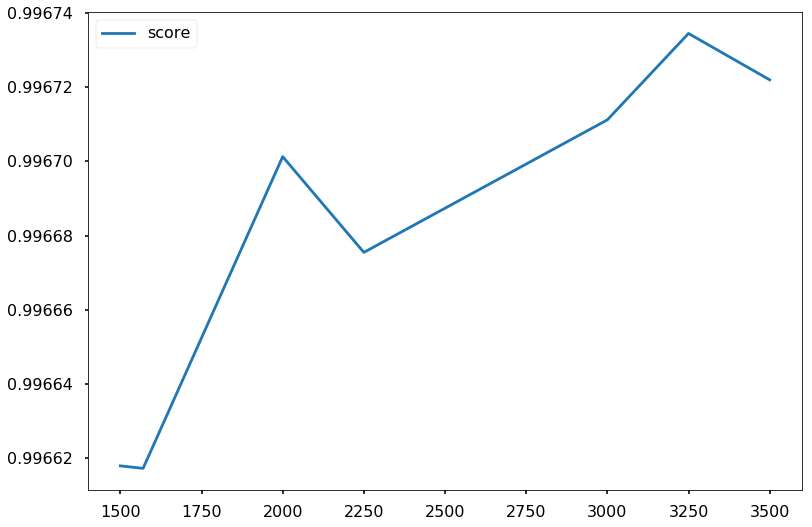

```python
pd.DataFrame({'score':abgrid.cv_results_['mean_test_score']}, index=abgrid.cv_results_['param_adaboostclassifier__n_estimators']).plot()
```

```python
roc_auc_score(y_test, abgrid.predict(X_test))
```

```
0.96757739512200769
```

```python
abgrid.best_estimator_, abgrid.best_params_
```

```
(Pipeline(memory=None,
      steps=[('categoricaltransformer', CategoricalTransformer(columns=['favorite', 'interested', 'status', 'property_type', 'sale_type', 'source', 'state'])), ('dummyencoder', DummyEncoder()), ('imputer', Imputer(axis=0, copy=True, missing_values='NaN', strategy='median', verbose=0)), ('standardsca…
           learning_rate=1.0, n_estimators=3250, random_state=None))]),
 {'adaboostclassifier__n_estimators': 3250})
```